# Bayesian Econometrics

Murilo Pereira

1/29/2021

## Homework Assignment 1

1. We know that $s_{n} \mid \theta \sim \operatorname{Binomial}(n, \theta)$, then
   $$\operatorname{Pr}\left(s_{n} \mid \theta\right)=\frac{n !}{k !\left(n-s_{n}\right) !} \theta^{s_{n}}(1-\theta)^{n-s_{n}}, \text { for } s_{n}=0,1,2, \ldots, n$$
   and the likelihood function is
   $$L\left(\theta \mid s_{n},A\right) \propto \theta^{s_{n}}(1-\theta)^{n-s_{n}}$$
   Considering Prior A:$~\theta \sim \operatorname{Uniform}(0,1)$, which is equivalent to Prior B:$~\theta \sim \operatorname{Beta}(a, b)$ with $a=1$ and $b=1$. Therefore
   $$p(\theta \mid A)=\frac{\Gamma(a+b)}{\Gamma(a) \Gamma(b)} \theta^{a-1}(1-\theta)^{b-1}$$
   for $a=1$ and $b=1$. Calculating now the posterior we have that
   $$\begin{align}
   p(\theta~|s_n, A) & \propto \theta^{s_{n}}(1-\theta)^{n-s_{n}}\theta^{a-1}(1-\theta)^{b-1} \\
   & \propto \theta^{a+s_n-1}(1-\theta)^{b+n-s_n-1}
   \end{align}$$
   and $(\theta~|(s_n,A)) \sim \operatorname{Beta}(a+s_n,b+n-s_n)$. Hence, $(\theta~|(s_n,A)) \sim \operatorname{Beta}(8,4)$.
2. Following the same procedure as in item (a), the likelihood function in this case is
   $$L\left(\theta \mid s_{n},B\right) \propto \theta^{s_{n}}(1-\theta)^{n-s_{n}}$$
   and now considering the Prior B:$~\theta \sim \operatorname{Beta}(a, b)$ with $a=4$ and $b=2$, we have that
   $$\begin{align}
   p(\theta~|s_n, B) & \propto \theta^{s_{n}}(1-\theta)^{n-s_{n}}\theta^{a-1}(1-\theta)^{b-1} \\
   & \propto \theta^{a+s_n-1}(1-\theta)^{b+n-s_n-1}
   \end{align}$$
   Substituting $a=4, b=2, n=10$ and $s_n=7$, $(\theta~|s_n, B) \sim \operatorname{Beta}(11,5)$.
3. Computing the predictive densities
   $$\begin{align}
   \operatorname{Pr}\left(s_{n} \mid A\right) &=\frac{\operatorname{Pr}\left(s_{n} \mid \theta\right) p(\theta \mid A)}{p\left(\theta \mid s_{n}, A\right)} \\ &= \int_0^1\theta^7(1-\theta)^3\theta^{a-1}(1-\theta)^{b-1}d\theta
   \end{align}$$
   where $a=1$ and $b=1$. Computing now the scalar:

```r
thetas = seq(0,1,length=1000)
post_A <- thetas^7*(1-thetas)^3
p <- sum(post_A*(thetas[2]-thetas[1]))
p
```

```
## [1] 0.0007575758
```

$$\begin{align}
\operatorname{Pr}\left(s_{n} \mid B\right)&=\frac{\operatorname{Pr}\left(s_{n} \mid \theta\right) p(\theta \mid B)}{p\left(\theta \mid s_{n}, B\right)}\\ &=\int_0^1\theta^7(1-\theta)^3\theta^{a-1}(1-\theta)^{b-1}d\theta
\end{align}$$
where $a=4$ and $b=2$. Computing now the scalar:

```r
post_B <- thetas^10*(1-thetas)^4
p <- sum(post_B*(thetas[2]-thetas[1]))
p
```

```
## [1] 6.660007e-05
```

4. Now we have the prior C:$\log (\theta /(1-\theta)) \sim \operatorname{Normal}\left(\mu, \sigma^{2}\right)$, then
   $$p(\theta \mid C)=\left(2 \pi \sigma^{2}\right)^{-1 / 2} \exp \left\{-\frac{1}{2 \sigma^{2}}\left[\log \left(\frac{\theta}{1-\theta}\right)-\mu\right]^{2}\right\} \frac{1}{\theta(1-\theta)}$$
   In order to calculate the posterior we have to compute
   $$p\left(\theta \mid s_{n}, C\right)=\frac{\left.p\left(s_{n} \mid \theta\right)\right) p(\theta \mid C)}{\int_{0}^{1} p\left(s_{n} \mid \theta\right) p(\theta \mid C) d \theta}=\frac{\left.p\left(s_{n} \mid \theta\right)\right) p(\theta \mid C)}{\operatorname{Pr}\left(s_{n} \mid C\right)}$$
   Note that in the expression the prior density and the likelihood function fail to conjugate, then we might use Monte Carlo Integration to approximate $\operatorname{Pr}\left(s_{n} \mid C\right)$
   $$p\left(\theta \mid s_{n}, C\right) \propto \theta^{s_{n}}(1-\theta)^{n-s_{n}}\exp \left\{-\frac{1}{2 \sigma^{2}}\left[\log \left(\frac{\theta}{1-\theta}\right)-\mu\right]^{2}\right\} \frac{1}{\theta(1-\theta)}$$
   calling $g(\theta) \equiv \theta^{s_{n}}(1-\theta)^{n-s_{n}}\exp \left\{-\frac{1}{2 \sigma^{2}}\left[\log \left(\frac{\theta}{1-\theta}\right)-\mu\right]^{2}\right\} \frac{1}{\theta(1-\theta)}$ we have
   $$p\left(\theta \mid s_{n}, C\right) \propto \dfrac{g(\theta)}{\int g(\theta)d\theta}$$
   The objective is to compute $E_{q}[h(\theta)]=\int h(\theta) q(\theta) d \theta$.
   $$I = \dfrac{g(\theta)}{\int g(\theta)d\theta} = \dfrac{\int \theta h(\theta)q(\theta)d\theta}{\int h(\theta)q(\theta)d\theta}$$
   where we have that $\theta^{(1)},...,\theta^{(m)} \sim q(\theta) \equiv \operatorname{Uniforme}(0,1)$ then,
   $$I = \dfrac{E_q(h_1(\theta))}{E_q(h_2(\theta))}$$
   where $h_1(\theta) = \dfrac{\theta g(\theta)}{q(\theta)}$. Defining now $I_{MC} = \dfrac{\dfrac{1}{M}\sum^m_{i=1} h_1(\theta^{(i)})}{\dfrac{1}{M}\sum^m_{i=1} h_2(\theta^{(i)})}$ we have that
   $$I_{MC} \to I ~~\textbf{when} ~~ M \to \infty$$
   Computing the normalizing constant, the prior predictive, via Monte Carlo integration:

```r
M = 10000
theta = runif(M)
pred = mean((theta^7*(1-theta)^3)*exp(-1/(2*3)*(log(theta/(1-theta))^2))*theta/(1-theta))
pred
```

```
## [1] 0.00151373
```

5. Comparing the three priors and posteriors Prior A

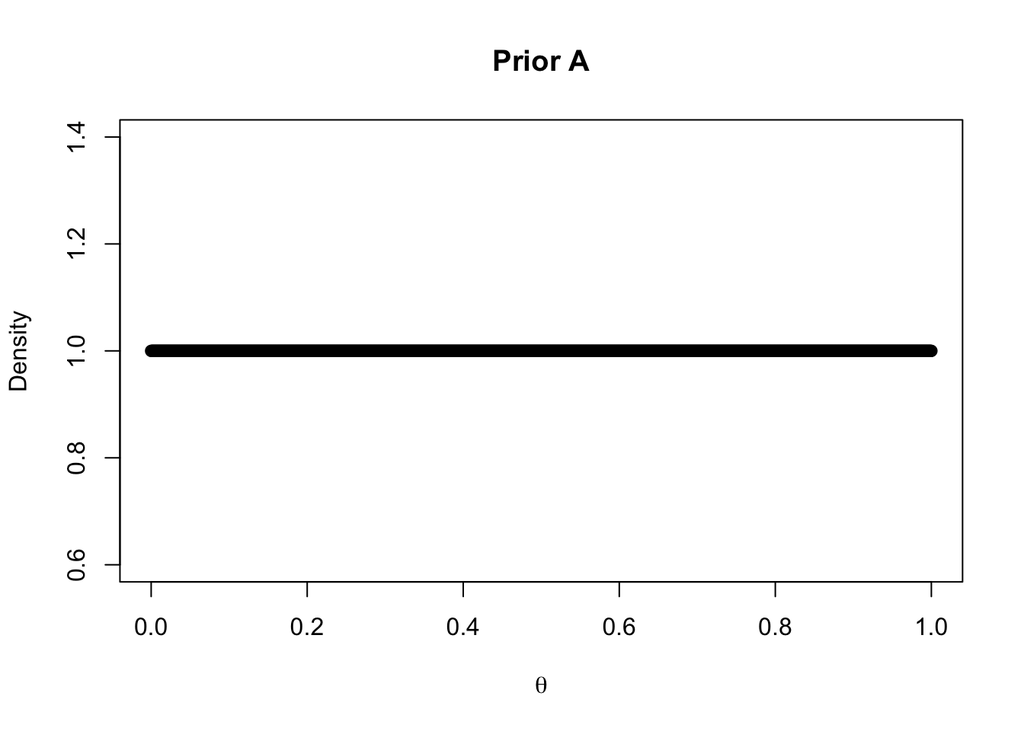

```r
thetas = seq(0,1,length=1000)
plot(thetas,dbeta(thetas,1,1),xlab = expression(theta),ylab = "Density",col=1)
title("Prior A")
```

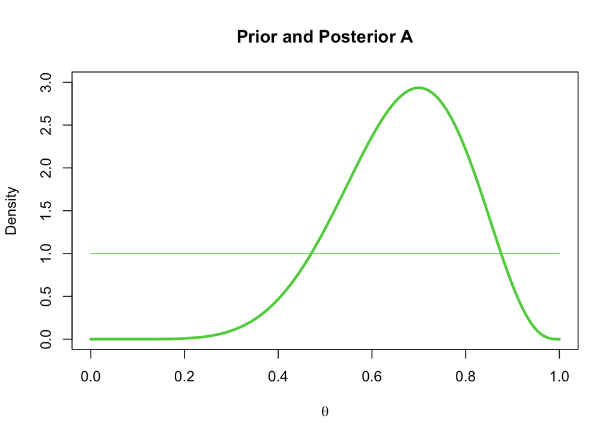

```r
post_A <- thetas^7*(1-thetas)^3
post_A <- post_A/sum(post_A*(thetas[2]-thetas[1]))

# Priors and posteriors
par(mfrow=c(1,1))
plot(thetas,dbeta(thetas,1,1),
type="l",ylim=c(0,3),xlab=expression(theta),ylab="Density",col=3)
lines(thetas,post_A,col=3,lwd=3)
title("Prior and Posterior A")
```

Prior B

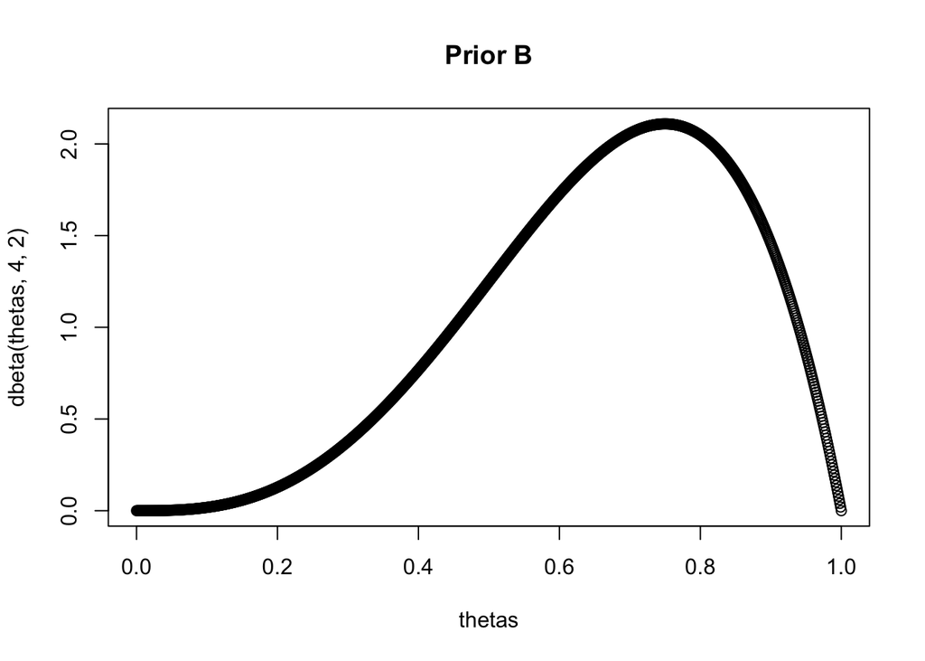

```r
thetas = seq(0,1,length=1000)
plot(thetas,dbeta(thetas,4,2))
title("Prior B")
```

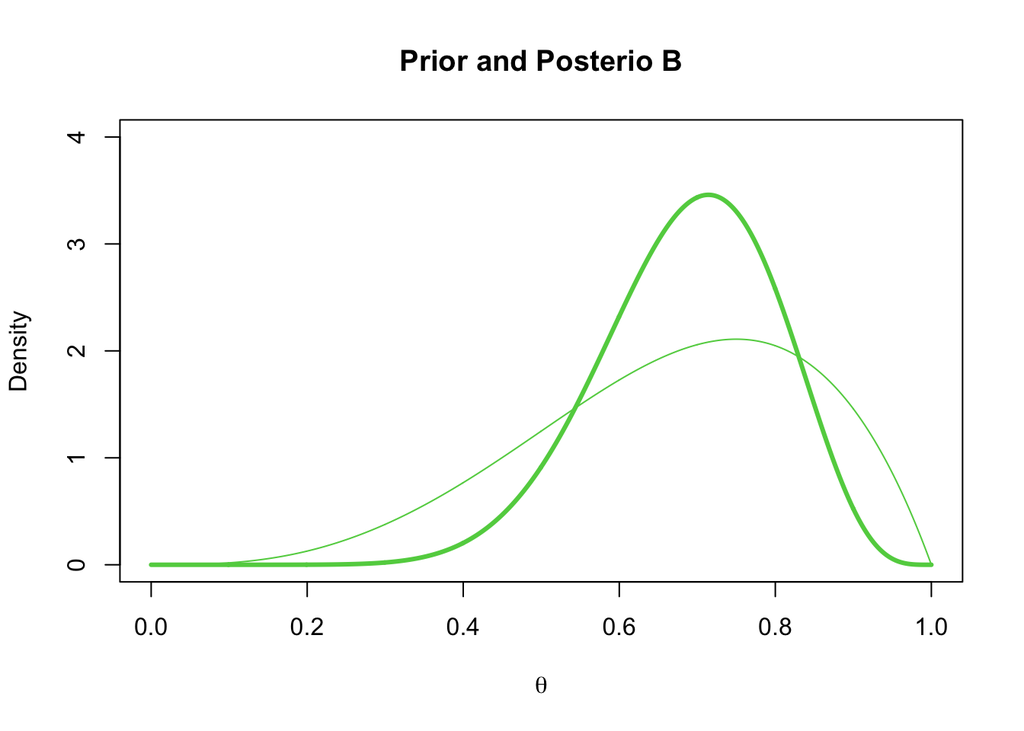

```r
post_B <- thetas^10*(1-thetas)^4
post_B <- post_B/sum(post_B*(thetas[2]-thetas[1]))

# Priors and posteriors
par(mfrow=c(1,1))
plot(thetas,dbeta(thetas,4,2),
type="l",ylim=c(0,4),xlab=expression(theta),ylab="Density",col=3)
title("Prior and Posterio B")
lines(thetas,post_B,col=3,lwd=3)
```

Prior C

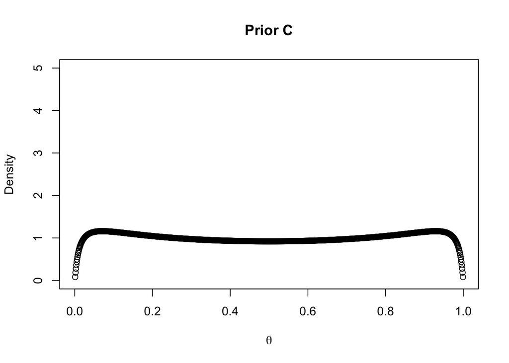

```r
prob = function(theta,mu,sig2){
  dnorm(log(theta/(1-theta)),mu,sqrt(sig2))/(theta*(1-theta))
}
thetas = seq(0.001,0.999,by=0.001)
par(mfrow=c(1,1))
plot(thetas,prob(thetas,0,3),ylim=c(0,5),xlab=expression(theta),ylab="Density")
title("Prior C")
```

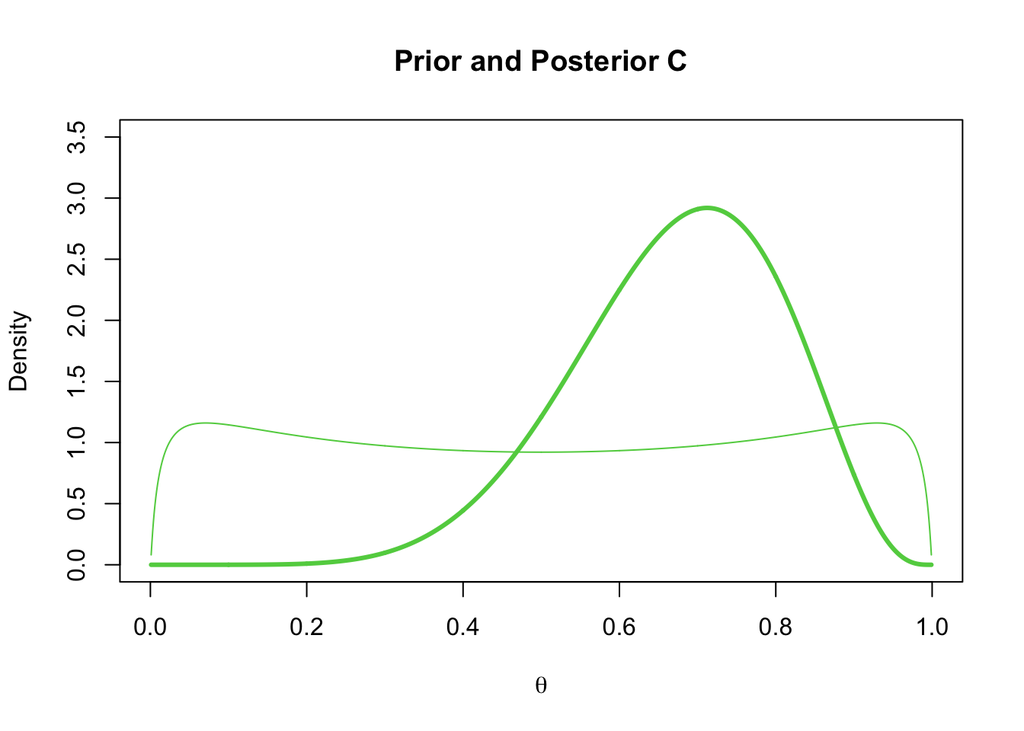

```r
# Posterior density
post_C = thetas^7*(1-thetas)^3*prob(thetas,0,3)
post_C = post_C/sum(post_C*(thetas[2]-thetas[1]))

# Priors and posteriors
par(mfrow=c(1,1))
plot(thetas,prob(thetas,0,3),
type="l",ylim=c(0,3.5),xlab=expression(theta),ylab="Density",col=3)
lines(thetas,post_C,col=3,lwd=3)
title("Prior and Posterior C")
```

6. Recall that the mean for a beta distribution is $E[x] = \dfrac{a}{a+b}$ and the variance is $V[x] = \dfrac{ab}{(a+b)^2(a+b+1)}$. Therefore, according to item (a) and (b) we can compute the mean and variance using $E[x] = \dfrac{a + s_n}{a+b+n}$ and $V[x] = \dfrac{(a+s_n)(b+n-s_n)}{(a+b+n)^2(a+b+n+1)}$